# Data Science Specialization Capstone Project: Predict the next word

Piyush Verma  
2017-03-17

### Background

This is the final submission for the fullfillment of [Coursera-John Hopkins Data Science Specialization Track Certificate](https://www.coursera.org/specializations/jhu-data-science). In this capstone project the final objective is to build a predictive tool in R Shiny app that can take a string of words from user as input anad predict the next word using [back-off](https://en.wikipedia.org/wiki/Katz%27s_back-off_model) model. Following concepts were used in this capstone project:

- [Text Mining](https://rpubs.com/vermaph/milestone): Uses of 'tm' package for data cleaning and corpus making
- [Back-off model](https://en.wikipedia.org/wiki/Katz%27s_back-off_model): Uses n-gram word counts to predict the next word. The theory tells us that the maximum likelihood estimator for words is proportional to their word frequencies.
- [R Shiny application](https://vermaph.shinyapps.io/Text_Prediction/)

### Description and Functionality

The R shiny application should take a string of characters from the user and and predict the next word as output. Here, the input can be n number of characters but the output will be restricted to just one word. Below is an screenshot of the application.

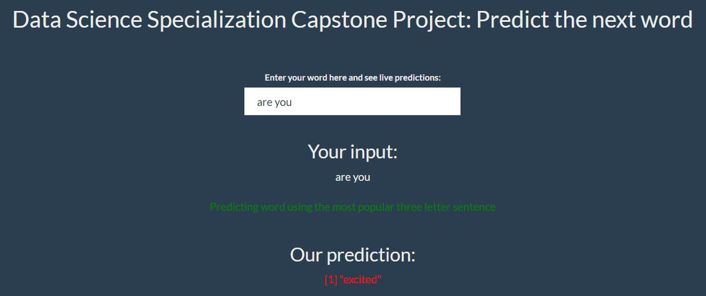

### How is it working? - N-Grams

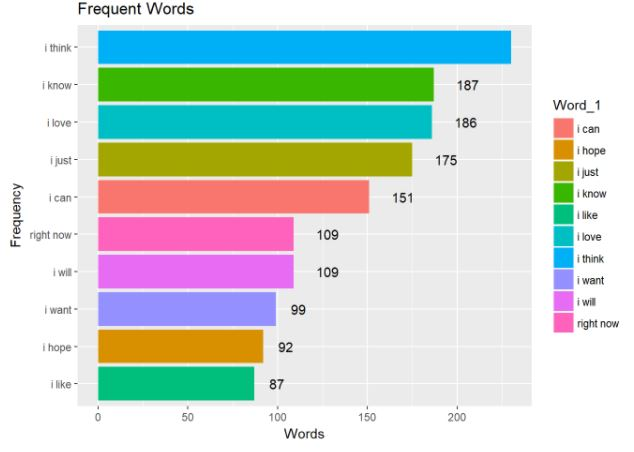

This app can be used as a POC to build more evolved products. For example, it can be used to predict a service complaint even before a customer finishes typing his complaint: possibly cutting down the critical customer service time

### References

- [R Pubs Milestone Report](https://rpubs.com/vermaph/milestone)
- R Pubs Final Presenatation
- [GitHub Code](https://github.com/grammilo/Codes/tree/master/Pet%20Projects/Text%20Mining%20-%20Word%20Prediction/Text_Prediction)
- [Back-Off model Wikipaedia](https://en.wikipedia.org/wiki/Katz%27s_back-off_model)